# Developing a model for loan risk estimation by Emadeldin_Fawaz

# Introduction

This project was conducted as part of a nano degree at Udacity. Because data v isualization and data science is a passion, I decided to limit the time to invest in this project to 30 working hours. The data used in this project is called “Loan Data Form Prosper” and it was supplied with the project instructions. However, it is also available online (please see the references). In this project, I aimed at visualizing the different variable separately and against each other. The idea was to try to identify a pattern or a relationship between the different variables. I aimed to develop and test a model that helps to predict one of the important variables (from my point of view). Eventually, I was successful in developing a simple 5 variable model that predicts the yield on loans quite successfully.

# Preliminary data investigation and understanding the dataframe

```
## Classes 'tbl_df', 'tbl' and 'data.frame':    113937 obs. of  81 variables:
##  $ ListingKey                         : chr  "1021339766868145413AB3B" "10273602499503308B223C1" "0EE9337825851032864889A" "0EF5356002482715299901A" ...
##  $ ListingNumber                      : int  193129 1209647 81716 658116 909464 1074836 750899 768193 1023355 1023355 ...
##  $ ListingCreationDate                : POSIXct, format: "2007-08-26 19:09:29" "2014-02-27 08:28:07" ...
##  $ CreditGrade                        : chr  "C" NA "HR" NA ...
##  $ Term                               : int  36 36 36 36 36 60 36 36 36 36 ...
##  $ LoanStatus                         : chr  "Completed" "Current" "Completed" "Current" ...
##  $ ClosedDate                         : POSIXct, format: "2009-08-14" NA ...
##  $ BorrowerAPR                        : num  0.165 0.12 0.283 0.125 0.246 ...
##  $ BorrowerRate                       : num  0.158 0.092 0.275 0.0974 0.2085 ...
##  $ LenderYield                        : num  0.138 0.082 0.24 0.0874 0.1985 ...
##  $ EstimatedEffectiveYield            : num  NA 0.0796 NA 0.0849 0.1832 ...
##  $ EstimatedLoss                      : num  NA 0.0249 NA 0.0249 0.0925 ...
##  $ EstimatedReturn                    : num  NA 0.0547 NA 0.06 0.0907 ...
##  $ ProsperRating (numeric)            : int  NA 6 NA 6 3 5 2 4 7 7 ...
##  $ ProsperRating (Alpha)              : chr  NA "A" NA "A" ...
##  $ ProsperScore                       : num  NA 7 NA 9 4 10 2 4 9 11 ...
##  $ ListingCategory (numeric)          : int  0 2 0 16 2 1 1 2 7 7 ...
##  $ BorrowerState                      : chr  "CO" "CO" "GA" "GA" ...
##  $ Occupation                         : chr  "Other" "Professional" "Other" "Skilled Labor" ...
##  $ EmploymentStatus                   : chr  "Self-employed" "Employed" "Not available" "Employed" ...
##  $ EmploymentStatusDuration           : int  2 44 NA 113 44 82 172 103 269 269 ...
##  $ IsBorrowerHomeowner                : chr  "True" "False" "False" "True" ...
##  $ CurrentlyInGroup                   : chr  "True" "False" "True" "False" ...
##  $ GroupKey                           : chr  NA NA "783C3371218786870A73D20" NA ...
##  $ DateCreditPulled                   : POSIXct, format: "2007-08-26 18:41:46" "2014-02-27 08:28:14" ...
##  $ CreditScoreRangeLower              : int  640 680 480 800 680 740 680 700 820 820 ...
##  $ CreditScoreRangeUpper              : int  659 699 499 819 699 759 699 719 839 839 ...
##  $ FirstRecordedCreditLine            : POSIXct, format: "2001-10-11" "1996-03-18" ...
##  $ CurrentCreditLines                 : int  5 14 NA 5 19 21 10 6 17 17 ...
##  $ OpenCreditLines                    : int  4 14 NA 5 19 17 7 6 16 16 ...
##  $ TotalCreditLinespast7years         : int  12 29 3 29 49 49 20 10 32 32 ...
##  $ OpenRevolvingAccounts              : int  1 13 0 7 6 13 6 5 12 12 ...
##  $ OpenRevolvingMonthlyPayment        : num  24 389 0 115 220 1410 214 101 219 219 ...
##  $ InquiriesLast6Months               : int  3 3 0 0 1 0 0 3 1 1 ...
##  $ TotalInquiries                     : num  3 5 1 1 9 2 0 16 6 6 ...
##  $ CurrentDelinquencies               : int  2 0 1 4 0 0 0 0 0 0 ...
##  $ AmountDelinquent                   : num  472 0 NA 10056 0 ...
##  $ DelinquenciesLast7Years            : int  4 0 0 14 0 0 0 0 0 0 ...
##  $ PublicRecordsLast10Years           : int  0 1 0 0 0 0 0 1 0 0 ...
```

[output cut: 199 more lines]

```
##   .. ..$ LP_NonPrincipalRecoverypayments    : list()
##   .. .. ..- attr(*, "class")= chr  "collector_double" "collector"
##   .. ..$ PercentFunded                      : list()
##   .. .. ..- attr(*, "class")= chr  "collector_double" "collector"
##   .. ..$ Recommendations                    : list()
##   .. .. ..- attr(*, "class")= chr  "collector_integer" "collector"
##   .. ..$ InvestmentFromFriendsCount         : list()
##   .. .. ..- attr(*, "class")= chr  "collector_integer" "collector"
##   .. ..$ InvestmentFromFriendsAmount        : list()
##   .. .. ..- attr(*, "class")= chr  "collector_double" "collector"
##   .. ..$ Investors                          : list()
##   .. .. ..- attr(*, "class")= chr  "collector_integer" "collector"
##   ..$ default: list()
##   .. ..- attr(*, "class")= chr  "collector_guess" "collector"
##   ..- attr(*, "class")= chr "col_spec"
```

```
##   ListingKey        ListingNumber     ListingCreationDate
##  Length:113937      Min.   :      4   Min.   :2005-11-09 20:44:28
##  Class :character   1st Qu.: 400919   1st Qu.:2008-09-19 10:02:14
##  Mode  :character   Median : 600554   Median :2012-06-16 12:37:19
##                     Mean   : 627886   Mean   :2011-07-09 08:07:23
##                     3rd Qu.: 892634   3rd Qu.:2013-09-09 19:40:48
##                     Max.   :1255725   Max.   :2014-03-10 12:20:53
##
##  CreditGrade             Term        LoanStatus
##  Length:113937      Min.   :12.00   Length:113937
##  Class :character   1st Qu.:36.00   Class :character
##  Mode  :character   Median :36.00   Mode  :character
##                     Mean   :40.83
##                     3rd Qu.:36.00
##                     Max.   :60.00
##
##    ClosedDate                   BorrowerAPR       BorrowerRate
##  Min.   :2005-11-25 00:00:00   Min.   :0.00653   Min.   :0.0000
##  1st Qu.:2009-07-14 00:00:00   1st Qu.:0.15629   1st Qu.:0.1340
##  Median :2011-04-05 00:00:00   Median :0.20976   Median :0.1840
##  Mean   :2011-03-07 20:21:21   Mean   :0.21883   Mean   :0.1928
##  3rd Qu.:2013-01-30 00:00:00   3rd Qu.:0.28381   3rd Qu.:0.2500
##  Max.   :2014-03-10 00:00:00   Max.   :0.51229   Max.   :0.4975
##  NA's   :58848                 NA's   :25
##   LenderYield      EstimatedEffectiveYield EstimatedLoss
##  Min.   :-0.0100   Min.   :-0.183          Min.   :0.005
##  1st Qu.: 0.1242   1st Qu.: 0.116          1st Qu.:0.042
##  Median : 0.1730   Median : 0.162          Median :0.072
##  Mean   : 0.1827   Mean   : 0.169          Mean   :0.080
##  3rd Qu.: 0.2400   3rd Qu.: 0.224          3rd Qu.:0.112
##  Max.   : 0.4925   Max.   : 0.320          Max.   :0.366
##                    NA's   :29084           NA's   :29084
##  EstimatedReturn  ProsperRating (numeric) ProsperRating (Alpha)
##  Min.   :-0.183   Min.   :1.000           Length:113937
##  1st Qu.: 0.074   1st Qu.:3.000           Class :character
##  Median : 0.092   Median :4.000           Mode  :character
##  Mean   : 0.096   Mean   :4.072
##  3rd Qu.: 0.117   3rd Qu.:5.000
##  Max.   : 0.284   Max.   :7.000
##  NA's   :29084    NA's   :29084
```

[output cut: 177 more lines]

```
##  Min.   :    0.00                Min.   :0.7000   Min.   : 0.00000
##  1st Qu.:    0.00                1st Qu.:1.0000   1st Qu.: 0.00000
##  Median :    0.00                Median :1.0000   Median : 0.00000
##  Mean   :   25.14                Mean   :0.9986   Mean   : 0.04803
##  3rd Qu.:    0.00                3rd Qu.:1.0000   3rd Qu.: 0.00000
##  Max.   :21117.90                Max.   :1.0125   Max.   :39.00000
##
##  InvestmentFromFriendsCount InvestmentFromFriendsAmount   Investors
##  Min.   : 0.00000           Min.   :    0.00            Min.   :   1.00
##  1st Qu.: 0.00000           1st Qu.:    0.00            1st Qu.:   2.00
##  Median : 0.00000           Median :    0.00            Median :  44.00
##  Mean   : 0.02346           Mean   :   16.55            Mean   :  80.48
##  3rd Qu.: 0.00000           3rd Qu.:    0.00            3rd Qu.: 115.00
##  Max.   :33.00000           Max.   :25000.00            Max.   :1189.00
##
```

The data is relatively large (113937 observations of 81 variables). I am concerned that running any code on such huge dataframe will take too long. I will generate a sub-dataframe of randomly selected 12000 observations (around 10% of the total observations) to be my working dataframe (named: subfd). I will explore the subset of the dataframe to see if I can come up with a plausible hypothesis. Then I will test my hypothesis on the full dataframe.

```
##   ListingKey        ListingNumber     ListingCreationDate
##  Length:12000       Min.   :      4   Min.   :2005-11-09 20:44:28
##  Class :character   1st Qu.: 416497   1st Qu.:2009-07-14 12:00:53
##  Mode  :character   Median : 601062   Median :2012-06-18 11:28:26
##                     Mean   : 632123   Mean   :2011-07-21 11:13:44
##                     3rd Qu.: 900186   3rd Qu.:2013-09-14 10:28:56
##                     Max.   :1255725   Max.   :2014-03-10 12:20:53
##
##  CreditGrade             Term        LoanStatus
##  Length:12000       Min.   :12.00   Length:12000
##  Class :character   1st Qu.:36.00   Class :character
##  Mode  :character   Median :36.00   Mode  :character
##                     Mean   :41.04
##                     3rd Qu.:36.00
##                     Max.   :60.00
##
##    ClosedDate                   BorrowerAPR       BorrowerRate
##  Min.   :2005-11-25 00:00:00   Min.   :0.01548   Min.   :0.0005
##  1st Qu.:2009-07-11 18:00:00   1st Qu.:0.15713   1st Qu.:0.1349
##  Median :2011-04-25 12:00:00   Median :0.21025   Median :0.1840
##  Mean   :2011-03-12 15:16:38   Mean   :0.21991   Mean   :0.1937
##  3rd Qu.:2013-01-30 00:00:00   3rd Qu.:0.28544   3rd Qu.:0.2521
##  Max.   :2014-03-09 00:00:00   Max.   :0.50633   Max.   :0.4975
##  NA's   :6216                  NA's   :3
##   LenderYield      EstimatedEffectiveYield EstimatedLoss
##  Min.   :-0.0095   Min.   :-0.1816         Min.   :0.0049
##  1st Qu.: 0.1249   1st Qu.: 0.1192         1st Qu.:0.0424
##  Median : 0.1740   Median : 0.1616         Median :0.0724
##  Mean   : 0.1836   Mean   : 0.1698         Mean   :0.0807
##  3rd Qu.: 0.2413   3rd Qu.: 0.2254         3rd Qu.:0.1120
##  Max.   : 0.4800   Max.   : 0.3199         Max.   :0.3660
##                    NA's   :2997            NA's   :2997
##  EstimatedReturn   ProsperRating (numeric) ProsperRating (Alpha)
##  Min.   :-0.1816   Min.   :1.000           Length:12000
##  1st Qu.: 0.0746   1st Qu.:3.000           Class :character
##  Median : 0.0922   Median :4.000           Mode  :character
##  Mean   : 0.0967   Mean   :4.053
##  3rd Qu.: 0.1171   3rd Qu.:5.000
##  Max.   : 0.2538   Max.   :7.000
##  NA's   :2997      NA's   :2997
```

[output cut: 177 more lines]

```
##  Min.   :    0.00                Min.   :0.7000   Min.   :0.00000
##  1st Qu.:    0.00                1st Qu.:1.0000   1st Qu.:0.00000
##  Median :    0.00                Median :1.0000   Median :0.00000
##  Mean   :   24.81                Mean   :0.9987   Mean   :0.04508
##  3rd Qu.:    0.00                3rd Qu.:1.0000   3rd Qu.:0.00000
##  Max.   :12000.00                Max.   :1.0000   Max.   :9.00000
##
##  InvestmentFromFriendsCount InvestmentFromFriendsAmount   Investors
##  Min.   :0.00000            Min.   :    0.00            Min.   :   1.00
##  1st Qu.:0.00000            1st Qu.:    0.00            1st Qu.:   2.00
##  Median :0.00000            Median :    0.00            Median :  42.00
##  Mean   :0.02133            Mean   :   15.63            Mean   :  79.35
##  3rd Qu.:0.00000            3rd Qu.:    0.00            3rd Qu.: 114.00
##  Max.   :8.00000            Max.   :16000.00            Max.   :1035.00
##
```

```
##  [1] "ListingKey"
##  [2] "ListingNumber"
##  [3] "ListingCreationDate"
##  [4] "CreditGrade"
##  [5] "Term"
##  [6] "LoanStatus"
##  [7] "ClosedDate"
##  [8] "BorrowerAPR"
##  [9] "BorrowerRate"
## [10] "LenderYield"
## [11] "EstimatedEffectiveYield"
## [12] "EstimatedLoss"
## [13] "EstimatedReturn"
## [14] "ProsperRating (numeric)"
## [15] "ProsperRating (Alpha)"
```

[output cut: 66 more lines]

I compared some indicators between the full df and the subdf. Ignoring possible outliers, it looks like that my sub-dataframe could represent the original dataframe. Among the numerical indicators I looked at: Term, BorrowerRate, ProsperRating (numeric), EmploymentStatusDuration, AvailableBankcardCredit, StatedMonthlyIncome, and LoanOriginalAmount.

Interesting to notice that some people with a monthly income of more than $250,000 are applying for loans with max $35000.

I will focus on some variables that I think they are of particular interest to the model I am trying to build:-

Some variables are reflecting each other (like ProsperRating (numeric), ProsperRating (Alpha) and ProsperScore). So I will choose one of them in such cases. Some variables are included in others (like LenderYield: The Lender yield is equal to the interest rate on the loan less the servicing fee). So I will use only the LenderYield and not the BorrowerRate. GroupKey includes if the borrower was in a group or not. Thus the variable CurrentlyInGroup could be omitted.

Variables that could be of particular interest to my model are:

A. Numerical

1. “Term”  
2. “LenderYield”  
3. “EstimatedReturn”  
4. “ProsperScore”  
5. “EmploymentStatusDuration”  
6. “CreditScoreRangeLower”  
7. “CreditScoreRangeUpper”  
8. “CurrentCreditLines”  
9. “OpenCreditLines”  
10. “OpenRevolvingAccounts”  
11. “OpenRevolvingMonthlyPayment”  
12. “InquiriesLast6Months”  
13. “TotalInquiries” 14. “AmountDelinquent”  
15. “DelinquenciesLast7Years”  
16. “PublicRecordsLast10Years”  
17. “PublicRecordsLast12Months”  
18. “RevolvingCreditBalance”  
19. “BankcardUtilization”  
20. “AvailableBankcardCredit”  
21. “TotalTrades”  
22. “TradesNeverDelinquent (percentage)”  
23. “TradesOpenedLast6Months”  
24. “DebtToIncomeRatio”  
25. “IncomeRange”  
26. “StatedMonthlyIncome”  
27. “TotalProsperLoans”  
28. “OnTimeProsperPayments”  
29. “ProsperPaymentsLessThanOneMonthLate” 30. “ProsperPaymentsOneMonthPlusLate”  
31. “ProsperPrincipalBorrowed”  
32. “ProsperPrincipalOutstanding”  
33. “ScorexChangeAtTimeOfListing”  
34. “LoanCurrentDaysDelinquent”  
35. “LoanMonthsSinceOrigination”  
36. “LoanOriginalAmount”  
37. “MonthlyLoanPayment”  
38. “LP_CustomerPayments”  
39. “LP_CustomerPrincipalPayments”  
40. “LP_InterestandFees”  
41. “LP_NetPrincipalLoss”  
42. “PercentFunded”  
43. “Recommendations”  
44. “InvestmentFromFriendsCount”  
45. “InvestmentFromFriendsAmount”  
46. “Investors

B. Categorical

1. “CreditGrade”  
2. “LoanStatus” 3. “ListingCategory (numeric)”  
4. “Occupation”  
5. “EmploymentStatus”  
6. “IsBorrowerHomeowner”  
7. “IncomeVerifiable”  
8. “LoanOriginationQuarter” 9. “EmploymentStatus”

ListingCategory The category of the listing that the borrower selected when posting their listing: 0 - Not Available, 1 - Debt Consolidation, 2 - Home Improvement, 3 - Business, 4 - Personal Loan, 5 - Student Use, 6 - Auto, 7- Other, 8 - Baby&Adoption, 9 - Boat, 10 - Cosmetic Procedure, 11 - Engagement Ring, 12 - Green Loans, 13 - Household Expenses, 14 - Large Purchases, 15 - Medical/Dental, 16 - Motorcycle, 17 - RV, 18 - Taxes, 19 - Vacation, 20 - Wedding Loans

I will use box plots to explore the numerical variables and histograms to explore the categorical variables.

# Univariate Plots Section

I will use boxplots for plotting the numerical variables and histograms for plotting the categorical variables.

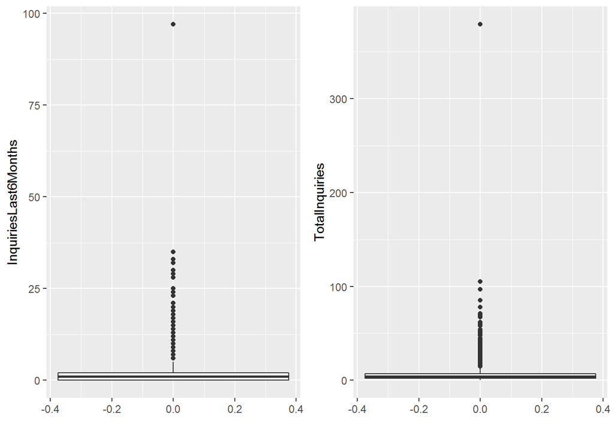

```
##
##  Pearson's product-moment correlation
##
## data:  InquiriesLast6Months and TotalInquiries
## t = 127.39, df = 11871, p-value < 2.2e-16
## alternative hypothesis: true correlation is not equal to 0
## 95 percent confidence interval:
##  0.7522435 0.7674452
## sample estimates:
##       cor
## 0.7599483
```

As expected, there is a very high correlation (rho > 0.7) between InquiriesLast6Months and TotalInquiries. Accordingly, in the model I will only use the most recent variable: InquiriesLast6Months

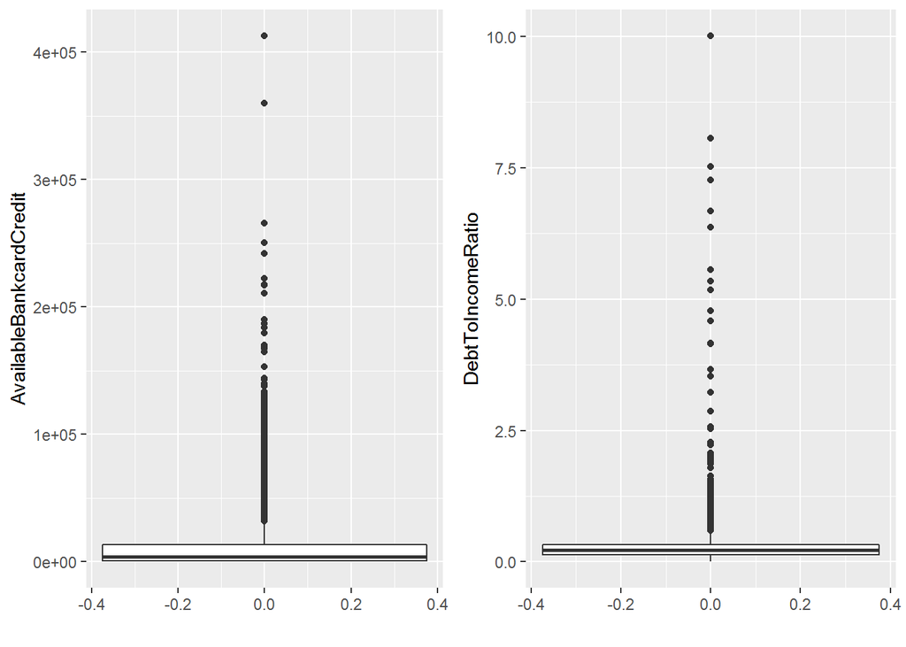

```
##    Min. 1st Qu.  Median    Mean 3rd Qu.    Max.    NA's
##       0     842    3937   11174   13242  412785     744
```

```
##    Min. 1st Qu.  Median    Mean 3rd Qu.    Max.    NA's
##  0.0000  0.1400  0.2200  0.2737  0.3200 10.0100     904
```

The majority of the people applying for the loans have very low dept to income ratio (75% are below 0.32) and very low Available Bank Card Credit (75% below $13,245). This is expected because the maximum loan in the data has the value of $35,000. With such small loans it is not expected that the majority of the customers are high earners.

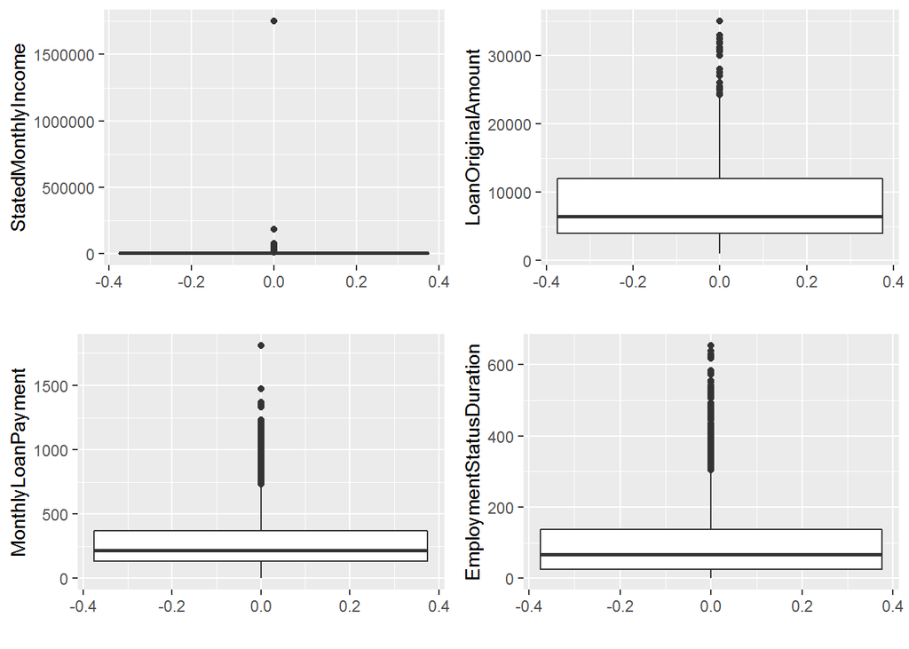

```
##    Min. 1st Qu.  Median    Mean 3rd Qu.    Max.
##       0    3242    4667    5733    6833 1750003
```

```
##    Min. 1st Qu.  Median    Mean 3rd Qu.    Max.
##    1000    4000    6500    8387   12000   35000
```

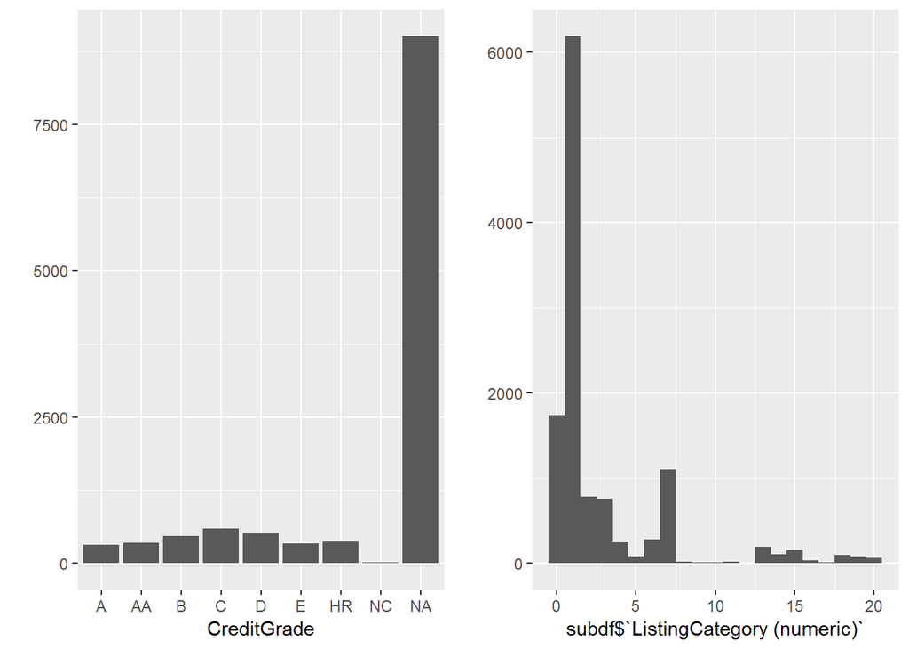

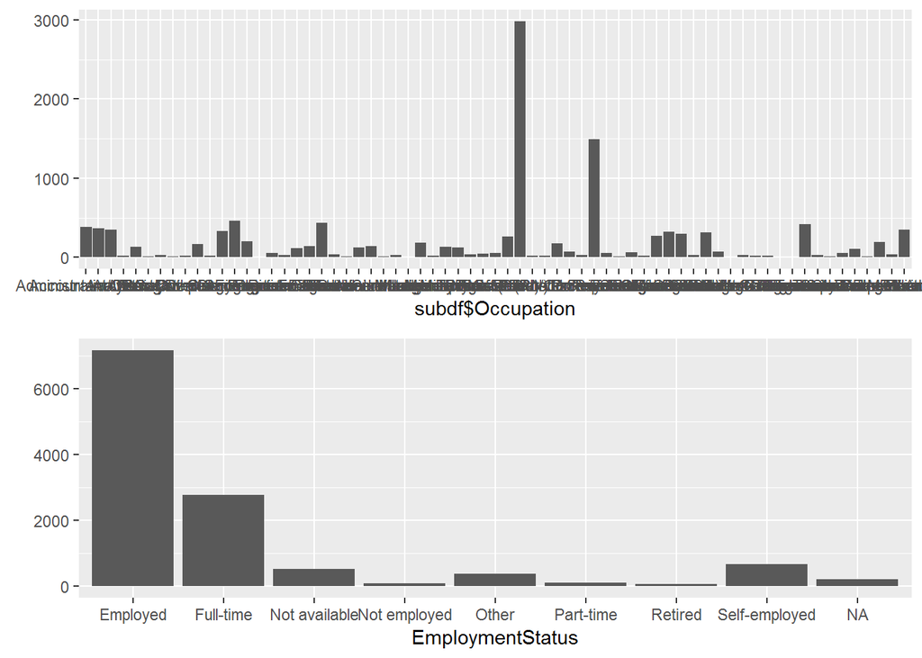

[output not shown]

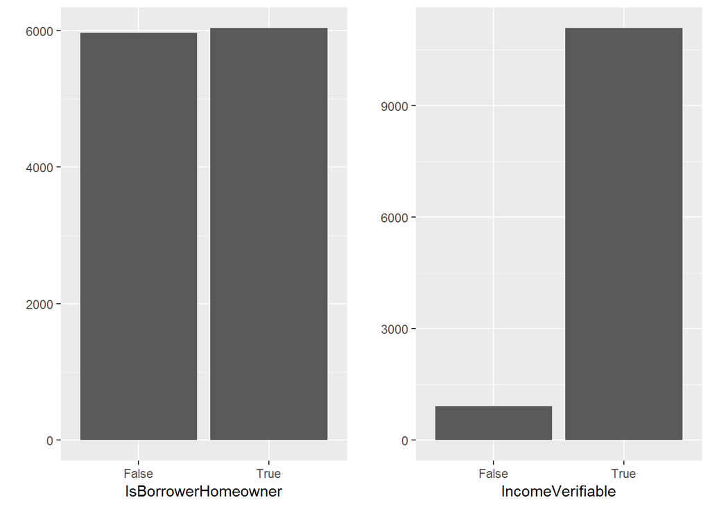

library(plotrix)

Too many occupations. The pie chart will not be adequate to summarize all data.

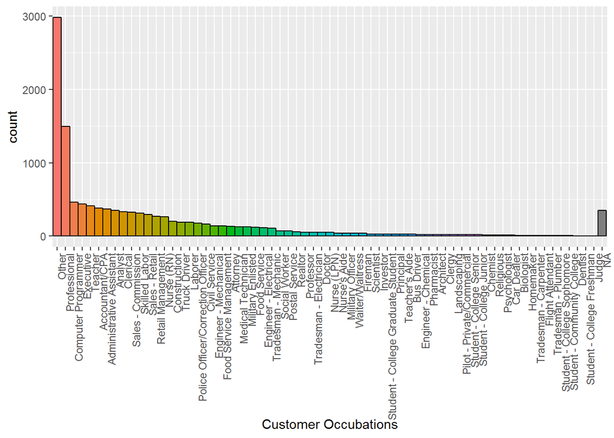

## Univariate Analysis

I used the univariate analysis to understand the characteristics of Loan Borrowers.

The majority of the customers have low dept to income ratio (75% are below 0.32) and low Available Bank Card Credit (75% below $13,245). This is expected because the maximum loan in the data has the value of $35,000. With such small loans it is not expected that the majority of the customers are high earners.

As expected, most of the borrowers are employees. Their income could be verified. Owning a house or not was almost equally distributed among applicants.

# Bivariate Plots Section

The most important dependent variables are: CreditGrade LoanStatus LenderYield

Other variables like estimated return will be correlated to one of these variables (by definition).

```
##
##  Pearson's product-moment correlation
##
## data:  LenderYield and EstimatedReturn
## t = 141.41, df = 9001, p-value < 2.2e-16
## alternative hypothesis: true correlation is not equal to 0
## 95 percent confidence interval:
##  0.8238999 0.8367273
## sample estimates:
##       cor
## 0.8304236
```

The LoanStatus & cridetGrade variable are categorical variables. It is better to transform them to numerical variables before proceeding

# understanding the vriables

## Finding most important independent variables

The majority of the applicants do not have recommendations and public records. Total prosper loans is mainly 1 or 2 (expected for employees) and most of its information is not available. The loans are mainly fully funded by the lender.

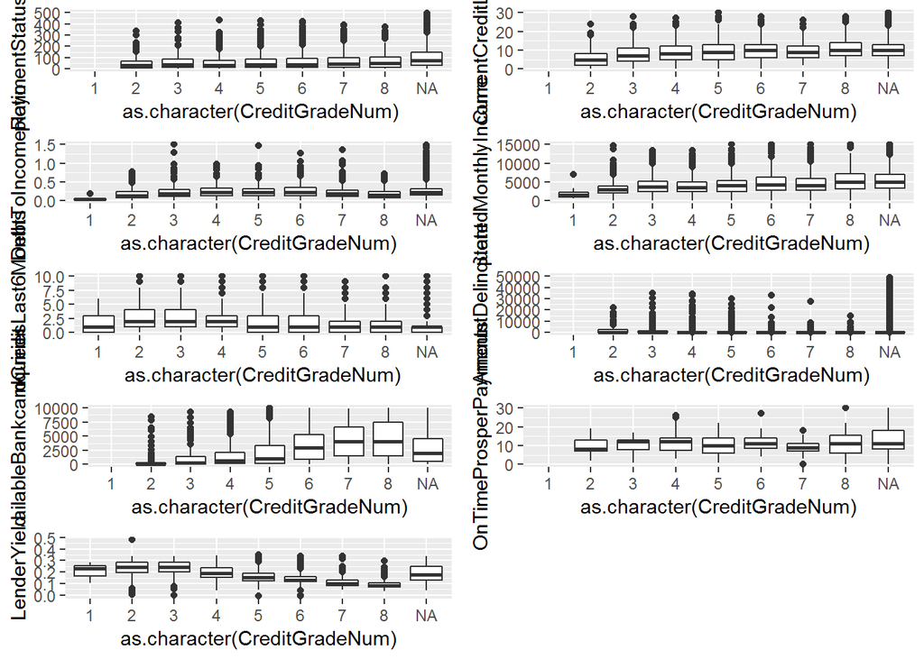

It looks like only two credit grades are strongly influenced by the duration of employment. AA credit grade has higher employment status duration and grade HR has lower employment status duration.The rest of the grades are not showing a particular pattern.

It is more obvious that the increase in current credit lines is associated with higher credit grades.

Dept to income ratio is not playing a significant role in the credit grade. This might be expected in this case because the data is more about employees. Dept to income ratio might be more decisive in corporate loans. It is hard to verify Dept in the case of people (unless they volunteeringly reveal) .

Stated monthly income is playing a role in deciding the credit grade. To some extent, the boxes are moving up with the better credit grades.

No risk no fun. As the credit grade decreases the lender yield increases

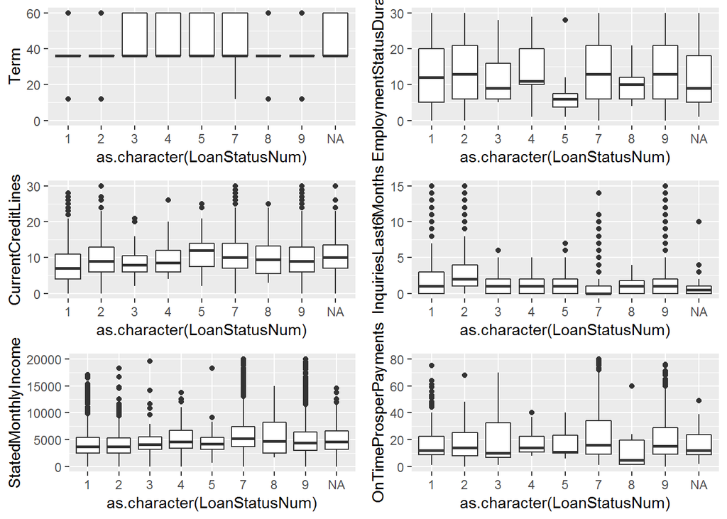

The majority of the loans were for 36 months. Loan Term is not affecting the status.

Duration of employment status is not affecting the loan status.

Loan status is getting better with increase in Current credit line.

Inquiries in the last 6 months do not affect loan status.

Stated monthly income is, to some extent, a decisive factor that enhances loan status.

On time prosper payment is not showing a specific pattern in relation to loan status.

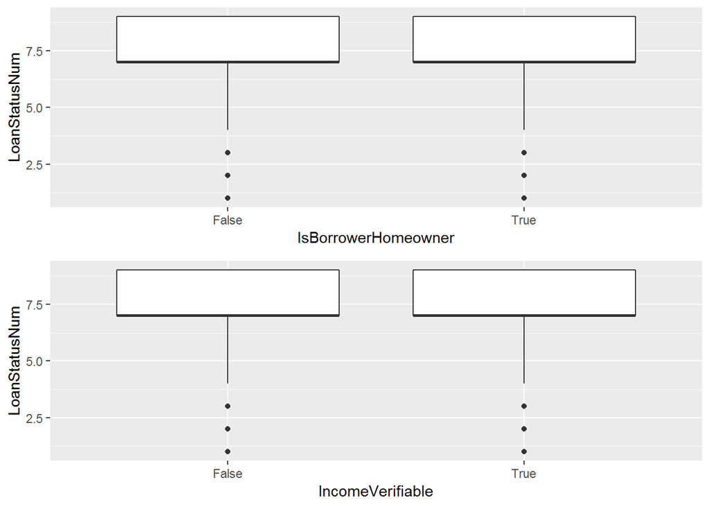

Home ownership and income verifiability are not significantly impacting loan status.

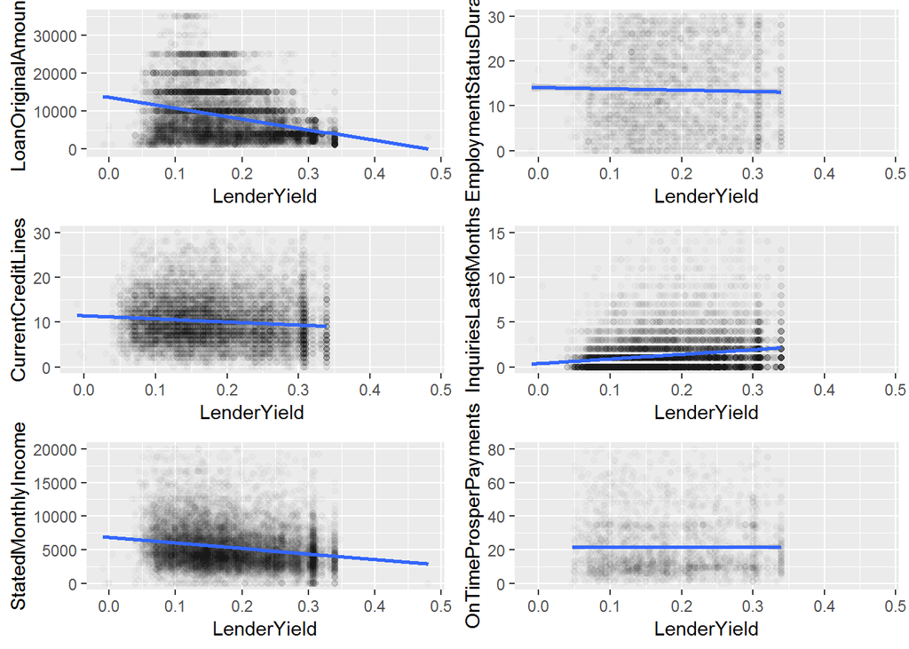

loan original amount and stated monthly income showed the strongest slope indicating that they have a stronger effect on lender yield.

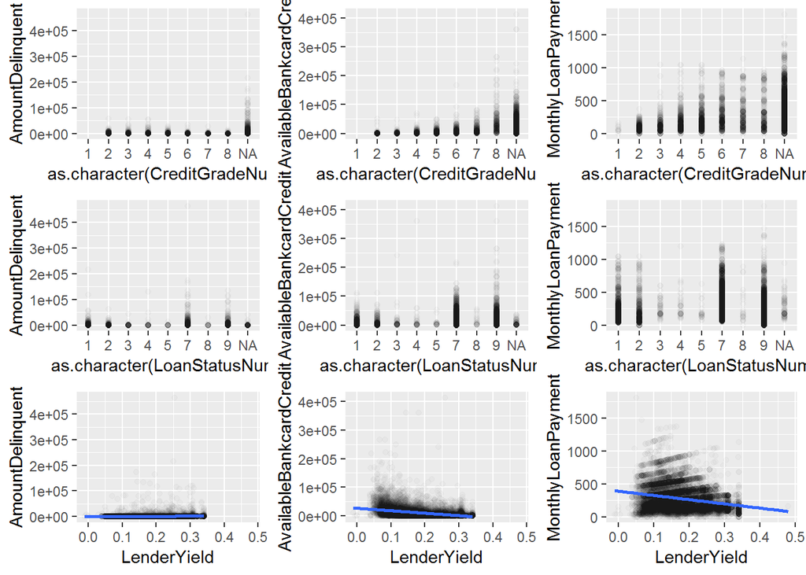

These three variables: AmountDelinquent, AvailableBankcardCredit and MonthlyLoanPayment are impacting the important dependent variables.

## Bivariate Analysis

Three variables are potential important outcomes in the model I am trying to develop. These are:

CreditGrade LoanStatus LenderYield

Out of the tested dependent variables, only 8 were identified that might influence the targeted dependent variables. These are: LoanOriginalAmount CurrentCreditLines InquiriesLast6Months StatedMonthlyIncome OnTimeProsperPayments AmountDelinquent AvailableBankcardCredit MonthlyLoanPayment

In the next section I will try to plot the most plausible relationships and develop and test a model.

# Multivariate Plots Section

## Extracting data for the model

## Plotting correlations Matrix

[output not shown]

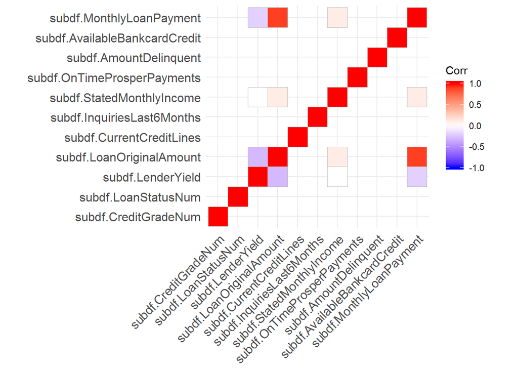

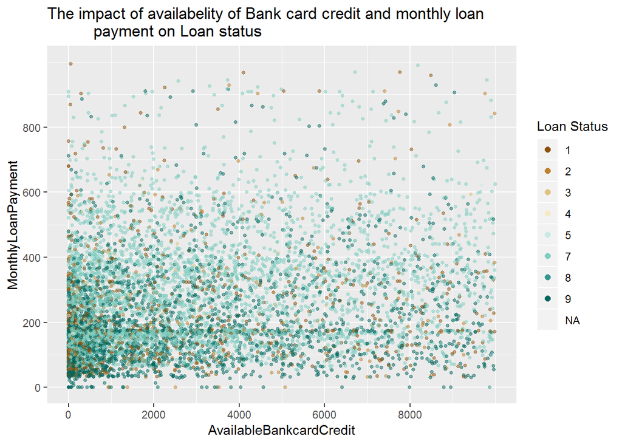

This graph does not indicate any obvious pattern.

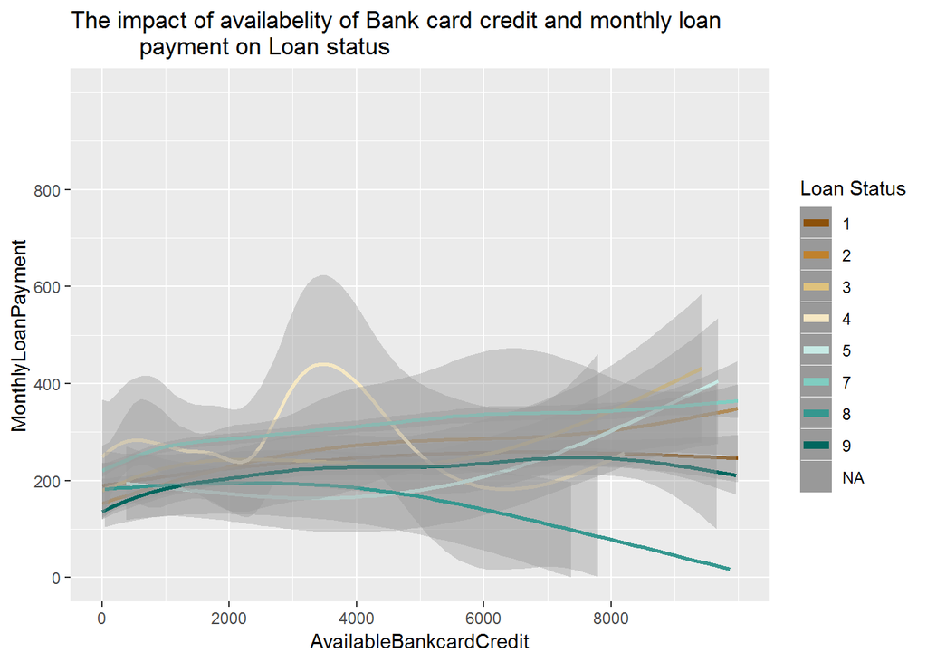

To some extent, better loan status are associated with lower monthly payment. The available Bank card credit does not affect the loan status.

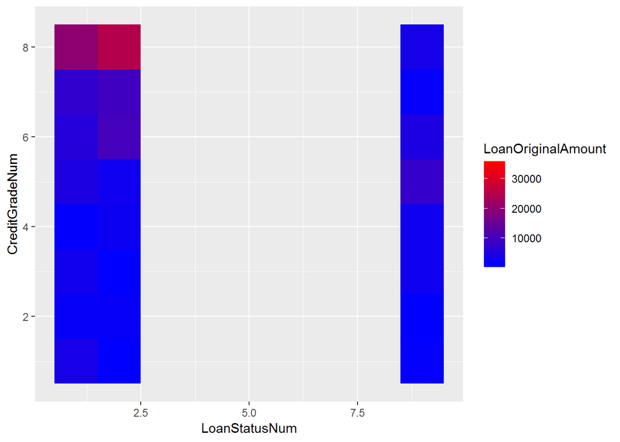

too many missing values. However, it looks like credit grade increases with loan original amount.

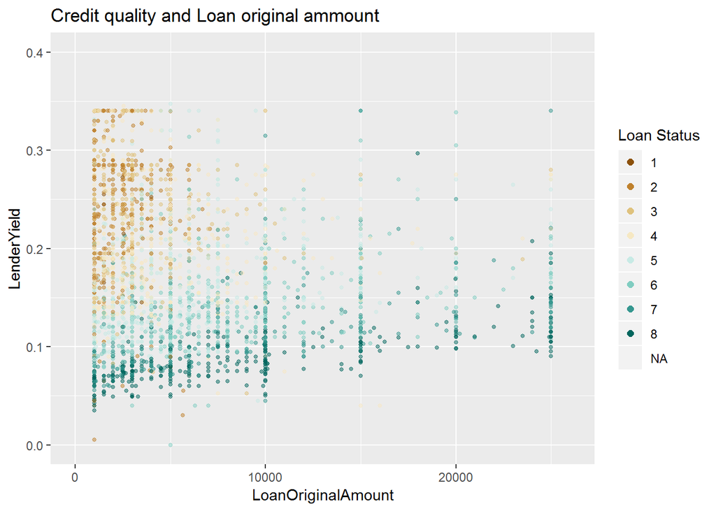

Loan original value is to some extent discrete. Most of the loans are taking the value of $5000 and its duplicates (10K, 15K, 20K and so on).

For good loans (paid on schedule), the lender yield is associated with loan original value.

```
##
## Calls:
## m1: lm(formula = LenderYield ~ I(AvailableBankcardCredit), data = subdf)
## m2: lm(formula = LenderYield ~ I(AvailableBankcardCredit) + LoanOriginalAmount,
##     data = subdf)
## m3: lm(formula = LenderYield ~ I(AvailableBankcardCredit) + LoanOriginalAmount +
##     MonthlyLoanPayment, data = subdf)
## m4: lm(formula = LenderYield ~ I(AvailableBankcardCredit) + LoanOriginalAmount +
##     MonthlyLoanPayment + InquiriesLast6Months, data = subdf)
## m5: lm(formula = LenderYield ~ I(AvailableBankcardCredit) + LoanOriginalAmount +
##     MonthlyLoanPayment + InquiriesLast6Months + OnTimeProsperPayments,
##     data = subdf)
##
## ========================================================================================================
##                                    m1             m2             m3             m4             m5
## --------------------------------------------------------------------------------------------------------
##   (Intercept)                      0.198***       0.224***       0.218***       0.210***      0.208***
##                                   (0.001)        (0.001)        (0.001)        (0.001)       (0.003)
##   I(AvailableBankcardCredit)      -0.000***      -0.000***      -0.000***      -0.000***     -0.000***
##                                   (0.000)        (0.000)        (0.000)        (0.000)       (0.000)
##   LoanOriginalAmount                             -0.000***      -0.000***      -0.000***     -0.000***
##                                                  (0.000)        (0.000)        (0.000)       (0.000)
##   MonthlyLoanPayment                                             0.000***       0.000***      0.000***
##                                                                 (0.000)        (0.000)       (0.000)
##   InquiriesLast6Months                                                          0.006***      0.008***
##                                                                                (0.000)       (0.001)
##   OnTimeProsperPayments                                                                       0.000
##                                                                                              (0.000)
## --------------------------------------------------------------------------------------------------------
##   R-squared                        0.110          0.186          0.208          0.233         0.267
##   adj. R-squared                   0.110          0.186          0.208          0.233         0.266
##   sigma                            0.071          0.068          0.067          0.066         0.067
##   F                             1389.782       1288.162        985.260        855.198       167.670
##   p                                0.000          0.000          0.000          0.000         0.000
##   Log-likelihood               13817.506      14322.420      14474.867      14653.803      2954.757
##   Deviance                        56.579         51.724         50.342         48.735        10.361
##   AIC                         -27629.013     -28636.840     -28939.735     -29295.606     -5895.514
##   BIC                         -27607.027     -28607.526     -28903.092     -29251.635     -5855.320
##   N                            11256          11256          11256          11254          2303
## ========================================================================================================
```

The model can only explain 26% of the variance. I tested many combinations including, for example, StatedMonthlyIncome however, it did not enhance the R^2 of the model.

# Testing a model

First selecting a random sample from the dataframe

```
##       subdf.CreditGradeNum subdf.LoanStatusNum subdf.LenderYield
## 411                      6                   9            0.1100
## 663                      5                   1            0.1895
## 4818                     4                   9            0.2225
## 4600                     2                   1            0.3400
## 454                      6                   9            0.1220
## 5245                     5                   2            0.3400
## 7150                     3                   9            0.3100
## 1563                     2                   2            0.1678
## 11921                    6                   9            0.1255
## 6693                     8                   9            0.0700
##       subdf.LoanOriginalAmount subdf.CurrentCreditLines
## 411                      10500                       16
## 663                      10000                       18
## 4818                      3500                        6
```

[output cut: 40 more lines]

```
##  [1] "subdf.CreditGradeNum"          "subdf.LoanStatusNum"
##  [3] "subdf.LenderYield"             "subdf.LoanOriginalAmount"
##  [5] "subdf.CurrentCreditLines"      "subdf.InquiriesLast6Months"
##  [7] "subdf.StatedMonthlyIncome"     "subdf.OnTimeProsperPayments"
##  [9] "subdf.AmountDelinquent"        "subdf.AvailableBankcardCredit"
## [11] "subdf.MonthlyLoanPayment"
```

```
##  [1] 1 1 1 1 1 1 1 1 1 1
##  [1] 1 1 1 1 1 1 1 1 1 1
##  [1] 1 1 1 1 1 1 1 1 1 1
##  [1] 1 1 1 1 1 1 1 1 1 1
##  [1] 1 1 1 1 1 1 1 1 1 1
##  [1] 1 1 1 1 1 1 1 1 1 1
##  [1] 1 1 1 1 1 1 1 1 1 1
##  [1] 1 1 1 1 1 1 1 1 1 1
##  [1] 1 1 1 1 1 1 1 1 1 1
##  [1] 1 1 1 1 1 1 1 1 1 1
##  [1] 1 1 1 1 1 1 1 1 1 1
```

### Double check

```
##         fit        lwr       upr
## 1 0.2231425 0.09134943 0.3549356
```

# Multivariate Analysis

To some extent, better loan status is associated with lower monthly payment. The available Bank card credit does not affect the loan status. However, it does affect the yield on loans. It looks like credit grade increases with original loan amount. Loan original amount is to some extent discrete. Most of the loans are taking the value of $5000 and its duplicates (10K, 15K, 20K and so on).

A model for predicting the yield on loans was generated using five variables. The developed model can explain 26% of the variance. I tested many combinations including, for example, StatedMonthlyIncome. However, it did not enhance the R^2 of the model.

The model was tested using randomly selected ten samples. The model perfectly predicts the lender yield within the upper and the lower 95% confidence intervals.

Indeed, more investigation is needed to intensively evaluate the accuracy of the model and assess other model parameters.

=================================================================

# Final Plots and Summary

### Plot One

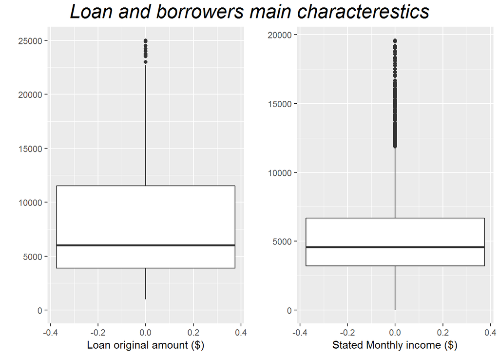

### Description One

Most of the borrowers are employees. The majority of the customers have low dept to income ratio (75% are below 0.32) and low Available Bank Card Credit (75% below $13,245). This is expected because the maximum loan in the data has the value of $35,000. With such small loans it is not expected that the majority of the customers are coorporate entities.

### Plot Two

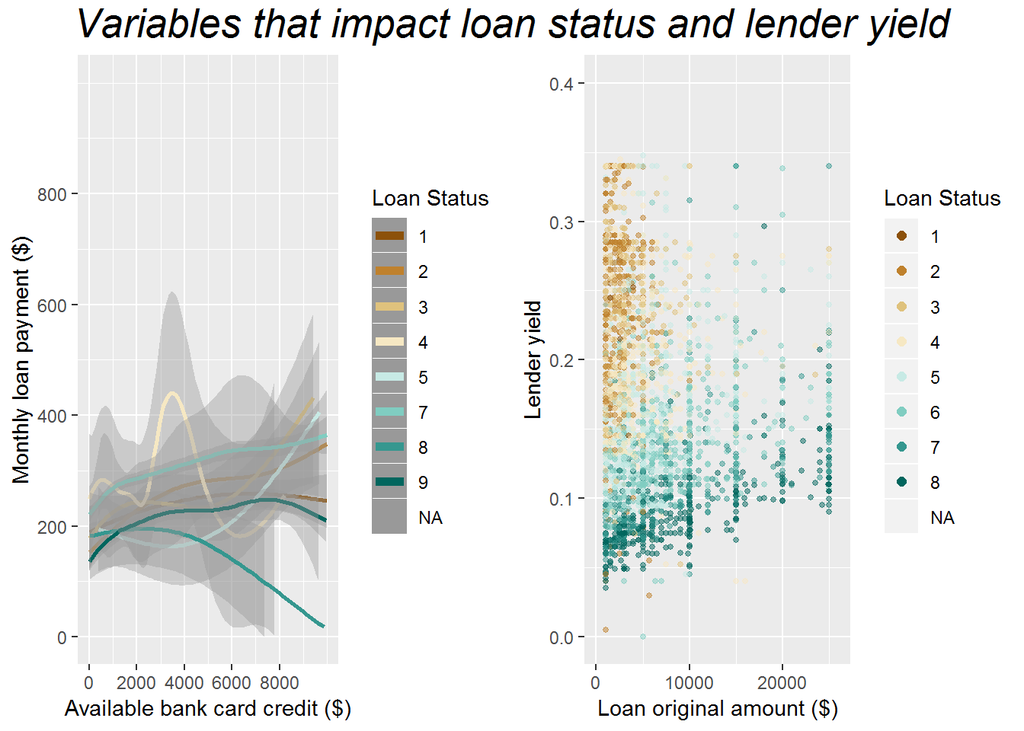

### Description Two

To some extent, better loan status are associated with lower monthly payment. Loan original value is to some extent discrete. Most of the loans are taking the value of $5000 and its duplicates (10K, 15K, 20K and so on).

For good loans (paid on schedule), the lender yield is associated with loan original value.

### Plot Three

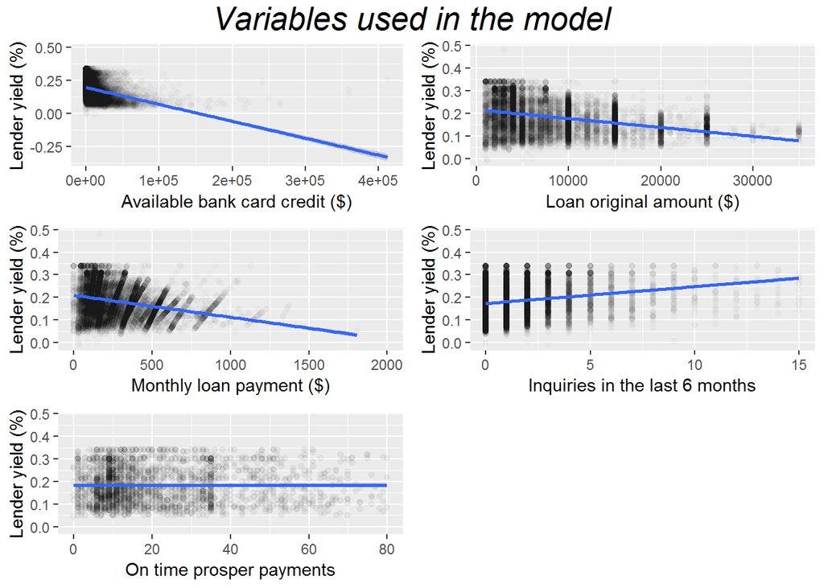

# Reflection

The developed model has an R square of 26% which is quite fair. However, when the model was tested using 10 random samples from the data, it was successful in predicting lender yield within the 95% confidence interval. This is quite impressing.

I limited the time to invest in this project to 30 working hours. If I had more time, I would continue in developing other models to predict other variables of interest.

There are many limitations for this model. First, the maximum loan value was only 35K. This model might work well with small personal loans. For corporate and large loans, more investigations must be conducted before reaching premature conclusions. Another limitation, I focussed only on a linear relationship. Probably exponential relationships exist in the data and revealing them might nhance the model accuracy.

# References

- Source of the Data https://s3.amazonaws.com/video.udacity-data.com/topher/2018/September/5babed58_data-set-options-explore-and-summarize-data-project/data-set-options-explore-and-summarize-data-project.pdf
- Variable definitions https://rpubs.com/mohohoh/ProsperDefinitions
- Code for random subset of a dataframe https://www.statmethods.net/management/subset.html
- R ifelse() Function https://www.datamentor.io/r-programming/ifelse-function/
- Sources for pie chart code https://stackoverflow.com/questions/33594642/beautiful-pie-charts-with-r

http://www.sthda.com/english/wiki/ggplot2-pie-chart-quick-start-guide-r-software-and-data-visualization

- Source for the code of the correlation matrix http://www.sthda.com/english/wiki/ggcorrplot-visualization-of-a-correlation-matrix-using-ggplot2
- Source for teh forcats code and teh bar plot https://stackoverflow.com/questions/42497063/r-sorting-factor-by-level-frequency-and-plotting

https://stackoverflow.com/questions/1330989/rotating-and-spacing-axis-labels-in-ggplot2